# Bank customers and predictions

### Goals

- Understand the customers of our bank
- Can a model be created to understand the causes of of customer churn and predict churning customers?

```python
import numpy as np
import pandas as pd
import matplotlib.pyplot as plt
import seaborn as sns
import plotly.express as ex
import plotly.graph_objs as go
import plotly.figure_factory as ff
from plotly.subplots import make_subplots
import plotly.offline as pyo
from sklearn.decomposition import PCA
from sklearn.model_selection import train_test_split,cross_val_score
from sklearn.ensemble import RandomForestClassifier,AdaBoostClassifier
from sklearn.svm import SVC
from sklearn.pipeline import Pipeline
from sklearn.preprocessing import StandardScaler
from sklearn.metrics import f1_score as f1
from sklearn.metrics import confusion_matrix
import scikitplot as skplt
from imblearn.over_sampling import SMOTE

plt.rc('figure',figsize=(18,9))
sns.set_style('darkgrid')
pyo.init_notebook_mode(connected=True)
```

```python
import plotly
plot_json = plotly.io.to_json(fig)
```

```python
df = pd.read_csv('bank-churn.csv')

# Remove last two columns as they contain results that we are trying to determine
df = df[df.columns[:-2]]
df.head(5)
```

|  | CLIENTNUM | Attrition_Flag | Customer_Age | Gender | Dependent_count | Education_Level | Marital_Status | Income_Category | Card_Category | Months_on_book | ... | Months_Inactive_12_mon | Contacts_Count_12_mon | Credit_Limit | Total_Revolving_Bal | Avg_Open_To_Buy | Total_Amt_Chng_Q4_Q1 | Total_Trans_Amt | Total_Trans_Ct | Total_Ct_Chng_Q4_Q1 | Avg_Utilization_Ratio |
| --- | --- | --- | --- | --- | --- | --- | --- | --- | --- | --- | --- | --- | --- | --- | --- | --- | --- | --- | --- | --- | --- |
| 0 | 768805383 | Existing Customer | 45 | M | 3 | High School | Married | $60K - $80K | Blue | 39 | ... | 1 | 3 | 12691.0 | 777 | 11914.0 | 1.335 | 1144 | 42 | 1.625 | 0.061 |
| 1 | 818770008 | Existing Customer | 49 | F | 5 | Graduate | Single | Less than $40K | Blue | 44 | ... | 1 | 2 | 8256.0 | 864 | 7392.0 | 1.541 | 1291 | 33 | 3.714 | 0.105 |
| 2 | 713982108 | Existing Customer | 51 | M | 3 | Graduate | Married | $80K - $120K | Blue | 36 | ... | 1 | 0 | 3418.0 | 0 | 3418.0 | 2.594 | 1887 | 20 | 2.333 | 0.000 |
| 3 | 769911858 | Existing Customer | 40 | F | 4 | High School | Unknown | Less than $40K | Blue | 34 | ... | 4 | 1 | 3313.0 | 2517 | 796.0 | 1.405 | 1171 | 20 | 2.333 | 0.760 |
| 4 | 709106358 | Existing Customer | 40 | M | 3 | Uneducated | Married | $60K - $80K | Blue | 21 | ... | 1 | 0 | 4716.0 | 0 | 4716.0 | 2.175 | 816 | 28 | 2.500 | 0.000 |

5 rows × 21 columns

```python
print(df.columns)
print(df.shape)
```

```
Index(['CLIENTNUM', 'Attrition_Flag', 'Customer_Age', 'Gender',
       'Dependent_count', 'Education_Level', 'Marital_Status',
       'Income_Category', 'Card_Category', 'Months_on_book',
       'Total_Relationship_Count', 'Months_Inactive_12_mon',
       'Contacts_Count_12_mon', 'Credit_Limit', 'Total_Revolving_Bal',
       'Avg_Open_To_Buy', 'Total_Amt_Chng_Q4_Q1', 'Total_Trans_Amt',
       'Total_Trans_Ct', 'Total_Ct_Chng_Q4_Q1', 'Avg_Utilization_Ratio'],
      dtype='object')
(10127, 21)
```

## Exploratory Data Analysis

```python
fig = make_subplots(rows=2, cols=1)

r1 = go.Box(x=df['Customer_Age'], name = 'Box Plot', boxmean=True)
r2 = go.Histogram(x=df['Customer_Age'], name = 'Histogram')

fig.add_trace(r1, row=1, col=1)
fig.add_trace(r2, row=2, col=1)

fig.update_layout(height=700, width=1200, title_text='Distribution of Customer Age')

fig.show()
```

[interactive chart not shown]

### It seems age follows a gaussian-ish distribution

So let's assume normality for ages

```python
fig = make_subplots(
    rows=2, cols=3,subplot_titles=('<b>Card Holders<b>','<b>Platinum Card Holders','<b>Blue Card Holders<b>', '<b>Silver Card Holders<b>', '<b>Gold Card Holders<b>', 'Residuals'),
    vertical_spacing=0.09,
    specs=[
        [{"type": "pie"}, {"type": "pie"}, None],
        [{"type": "pie"}, {"type": "pie"}, {"type": "pie"}]
    ]
)

fig.add_trace(
    go.Pie(values=df.Gender.value_counts().values,labels=['<b>Female<b>','<b>Male<b>'],
           #pull=[0,0.3]
          ),
    row=1, col=1
)

fig.add_trace(
    go.Pie(
        labels=['Female Platinum Card Holders','Male Platinum Card Holders'],
        values=df.query('Card_Category=="Platinum"').Gender.value_counts().values,
        #pull=[0,0.05,0.5]
    ),
    row=1, col=2
)

fig.add_trace(
    go.Pie(
        labels=['Female Blue Card Holders','Male Blue Card Holders'],
        values=df.query('Card_Category=="Blue"').Gender.value_counts().values,
        #pull=[0,0.2,0.5]
    ),
    row=2, col=1
)

fig.add_trace(
    go.Pie(
        labels=['Female Silver Card Holders','Male Silver Card Holders'],
        values=df.query('Card_Category=="Silver"').Gender.value_counts().values,
        #pull=[0,0.2,0.5]
    ),
    row=2, col=2
)

fig.add_trace(
    go.Pie(
        labels=['Female Gold Card Holders','Male Gold Card Holders'],
        values=df.query('Card_Category=="Gold"').Gender.value_counts().values,
        #pull=[0,0.2,0.5]
    ),
    row=2, col=3
)



fig.update_layout(
    height=800,
    showlegend=True,
    title_text="<b>Distribution Of Gender And Different Card Statuses<b>"
)

fig.show()
```

[interactive chart not shown]

### Slightly more female card holders than males, but there isn't a big difference

Let's assume the genders are distributed evenly

```python
fig = make_subplots(rows=2, cols=1)

tr1=go.Box(x=df['Dependent_count'],name='Box Plot',boxmean=True)
tr2=go.Histogram(x=df['Dependent_count'],name='Histogram')

fig.add_trace(tr1,row=1,col=1)
fig.add_trace(tr2,row=2,col=1)

fig.update_layout(height=700, width=1200, title_text="Distribution of Dependent counts (close family members)")
fig.show()
```

[interactive chart not shown]

```python
left = (904 + 1838 + 2655)
right = (2732 + 1574 + 424)

print(left, right)
```

```
5397 4730
```

### Distribution of dependents is guassian with a slight left lean

But only a *slight* lean to the left

```python
ex.pie(df,names='Education_Level',title='Education Levels', height=700, width=700)
```

[interactive chart not shown]

### Interestingly, 15% of customers have an unknown education status

### 50% of the customers have at least tertiary education

```python
ex.pie(df,names='Marital_Status',title='Marital Statuses', height=700, width=700)
```

[interactive chart not shown]

### This is kinda hard to understand but only 7% of customers are divorced

##### This could mean 2 things:

- Many younger customers (not true based on the age distribution)
- This bank does something for married people that it doesn't offer to divorcees (??)

```python
unique_values = df['Income_Category'].unique()
unique_values
```

```
array(['$60K - $80K', 'Less than $40K', '$80K - $120K', '$40K - $60K',
       '$120K +', 'Unknown'], dtype=object)
```

```python
df['Income_Category'] = df['Income_Category'].replace({'$60K - $80K': '60K-80K', 'Less than $40K': '<40K', '$80K - $120K':'80K-120K', '$40K - $60K':'40K-60K', '$120K +':'120K >', 'Unknown':'Unknown'})
```

```python
ex.pie(df,names='Income_Category',title='Income Levels', height=700, width=700)
```

[interactive chart not shown]

```python
ex.pie(df,names='Card_Category',title='Card Types', height=700, width=700)
```

[interactive chart not shown]

```python
fig = make_subplots(rows=2, cols=1)

r1=go.Box(x=df['Months_on_book'],name='Box Plot',boxmean=True)
r2=go.Histogram(x=df['Months_on_book'],name='Histogram')

fig.add_trace(r1,row=1,col=1)
fig.add_trace(r2,row=2,col=1)

fig.update_layout(height=700, width=1200, title_text="Member of Bank (Months)")
fig.show()
```

[interactive chart not shown]

### What happened 36 months ago??

```python
print('Kurtosis of Months on book features is: {}'.format(df['Months_on_book'].kurt()))
```

```
Kurtosis of Months on book features is: 0.40010012019986707
```

### Can't assume normality here due to low kurtosis (< 3)

```python
fig = make_subplots(rows=2, cols=1)

r1=go.Box(x=df['Total_Relationship_Count'],name='Box Plot',boxmean=True)
r2=go.Histogram(x=df['Total_Relationship_Count'],name='Histogram')

fig.add_trace(r1,row=1,col=1)
fig.add_trace(r2,row=2,col=1)

fig.update_layout(height=700, width=1200, title_text="Distribution of Total Number of Products Held by the customer")
fig.show()
```

[interactive chart not shown]

```python
from scipy.stats import shapiro, normaltest

stat, p = shapiro(df['Total_Relationship_Count'])
print('Shapiro-Wilk Test p-value:', p)

stat, p = normaltest(df['Total_Relationship_Count'])
print("D'Agostino's K^2 Test p-value:", p)
```

```
Shapiro-Wilk Test p-value: 0.0
D'Agostino's K^2 Test p-value: 0.0
```

### Data is definitely not distributed normally

More like it's evenly/uniformly distributed

```python
fig = make_subplots(rows=2, cols=1)

r1=go.Box(x=df['Months_Inactive_12_mon'],name='Box Plot',boxmean=True)
r2=go.Histogram(x=df['Months_Inactive_12_mon'],name='Histogram')

fig.add_trace(r1,row=1,col=1)
fig.add_trace(r2,row=2,col=1)

fig.update_layout(height=700, width=1200, title_text="Distribution of inactive months in the last 12 months")
fig.show()
```

[interactive chart not shown]

```python
fig = make_subplots(rows=2, cols=1)

r1=go.Box(x=df['Credit_Limit'],name='Box Plot',boxmean=True)
r2=go.Histogram(x=df['Credit_Limit'],name='Histogram')

fig.add_trace(r1,row=1,col=1)
fig.add_trace(r2,row=2,col=1)

fig.update_layout(height=700, width=1200, title_text="Distribution of the Credit Limit")
fig.show()
```

[interactive chart not shown]

### Most customers have a credit limit < 10,000

Though there is a group of customers with a limit > 35,000

```python
fig = make_subplots(rows=2, cols=1)

r1=go.Box(x=df['Total_Trans_Amt'],name='Box Plot',boxmean=True)
r2=go.Histogram(x=df['Total_Trans_Amt'],name='Histogram')

fig.add_trace(r1,row=1,col=1)
fig.add_trace(r2,row=2,col=1)

fig.update_layout(height=700, width=1200, title_text="Distribution of the Total Transaction Amount (Last 12 months)")
fig.show()
```

[interactive chart not shown]

```python
ex.pie(df,names='Attrition_Flag',title='Churning customers', height=700, width=700)
```

[interactive chart not shown]

### Only 16 % of customers are churn customers

**But we want to know how to predict what causes churn**

## Data cleaning and preprocessing

```python
df.Attrition_Flag = df.Attrition_Flag.replace({'Attrited Customer':1,'Existing Customer':0})
df.Gender = df.Gender.replace({'F':1,'M':0})
df = pd.concat([df,pd.get_dummies(df['Education_Level']).drop(columns=['Unknown'])],axis=1)
df = pd.concat([df,pd.get_dummies(df['Income_Category']).drop(columns=['Unknown'])],axis=1)
df = pd.concat([df,pd.get_dummies(df['Marital_Status']).drop(columns=['Unknown'])],axis=1)
df = pd.concat([df,pd.get_dummies(df['Card_Category']).drop(columns=['Platinum'])],axis=1)
df.drop(columns = ['Education_Level','Income_Category','Marital_Status','Card_Category','CLIENTNUM'],inplace=True)
```

```python
df.shape
```

```
(10127, 33)
```

```python
df.columns
```

```
Index(['Attrition_Flag', 'Customer_Age', 'Gender', 'Dependent_count',
       'Months_on_book', 'Total_Relationship_Count', 'Months_Inactive_12_mon',
       'Contacts_Count_12_mon', 'Credit_Limit', 'Total_Revolving_Bal',
       'Avg_Open_To_Buy', 'Total_Amt_Chng_Q4_Q1', 'Total_Trans_Amt',
       'Total_Trans_Ct', 'Total_Ct_Chng_Q4_Q1', 'Avg_Utilization_Ratio',
       'College', 'Doctorate', 'Graduate', 'High School', 'Post-Graduate',
       'Uneducated', '120K >', '40K-60K', '60K-80K', '80K-120K', '<40K',
       'Divorced', 'Married', 'Single', 'Blue', 'Gold', 'Silver'],
      dtype='object')
```

```python
fig = make_subplots(rows=2, cols=1,shared_xaxes=True,subplot_titles=('Perason Correlation',  'Spearman Correlation'))
colorscale=     [[1.0              , "rgb(165,0,38)"],
                [0.8888888888888888, "rgb(215,48,39)"],
                [0.7777777777777778, "rgb(244,109,67)"],
                [0.6666666666666666, "rgb(253,174,97)"],
                [0.5555555555555556, "rgb(254,224,144)"],
                [0.4444444444444444, "rgb(224,243,248)"],
                [0.3333333333333333, "rgb(171,217,233)"],
                [0.2222222222222222, "rgb(116,173,209)"],
                [0.1111111111111111, "rgb(69,117,180)"],
                [0.0               , "rgb(49,54,149)"]]

s_val =df.corr('pearson')
s_idx = s_val.index
s_col = s_val.columns
s_val = s_val.values
fig.add_trace(
    go.Heatmap(x=s_col,y=s_idx,z=s_val,name='pearson',showscale=False,xgap=0.7,ygap=0.7,colorscale=colorscale),
    row=1, col=1
)


s_val =df.corr('spearman')
s_idx = s_val.index
s_col = s_val.columns
s_val = s_val.values
fig.add_trace(
    go.Heatmap(x=s_col,y=s_idx,z=s_val,xgap=0.7,ygap=0.7,colorscale=colorscale),
    row=2, col=1
)
fig.update_layout(
    hoverlabel=dict(
        bgcolor="white",
        font_size=16,
        font_family="Rockwell"
    )
)
fig.update_layout(height=900, width=1200, title_text="Correlations")
fig.show()
```

[interactive chart not shown]

```python
oversample = SMOTE()
x, y = oversample.fit_resample(df[df.columns[1:]], df[df.columns[0]])
upsampled_df = x.assign(Churn = y)
```

```python
upsampled_df.to_csv('upsampled_df.csv', sep=',', index=False)
```

```python
ohe_data = upsampled_df[upsampled_df.columns[15:-1]].copy()

upsampled_df = upsampled_df.drop(columns=upsampled_df.columns[15:-1])
```

```python
fig = make_subplots(rows=2, cols=1,shared_xaxes=True,subplot_titles=('Pearson Correlation',  'Spearman Correlation'))
colorscale=     [[1.0              , "rgb(165,0,38)"],
                [0.8888888888888888, "rgb(215,48,39)"],
                [0.7777777777777778, "rgb(244,109,67)"],
                [0.6666666666666666, "rgb(253,174,97)"],
                [0.5555555555555556, "rgb(254,224,144)"],
                [0.4444444444444444, "rgb(224,243,248)"],
                [0.3333333333333333, "rgb(171,217,233)"],
                [0.2222222222222222, "rgb(116,173,209)"],
                [0.1111111111111111, "rgb(69,117,180)"],
                [0.0               , "rgb(49,54,149)"]]

s_val =upsampled_df.corr('pearson')
s_idx = s_val.index
s_col = s_val.columns
s_val = s_val.values
fig.add_trace(
    go.Heatmap(x=s_col,y=s_idx,z=s_val,name='pearson',showscale=False,xgap=1,ygap=1,colorscale=colorscale),
    row=1, col=1
)


s_val =upsampled_df.corr('spearman')
s_idx = s_val.index
s_col = s_val.columns
s_val = s_val.values
fig.add_trace(
    go.Heatmap(x=s_col,y=s_idx,z=s_val,xgap=1,ygap=1,colorscale=colorscale),
    row=2, col=1
)
fig.update_layout(
    hoverlabel=dict(
        bgcolor="white",
        font_size=16,
        font_family="Rockwell"
    )
)
fig.update_layout(height=900, width=1200, title_text="Upsampled Correlations")
fig.show()
```

[interactive chart not shown]

```python
pd.set_option('display.max_rows', None)

# For Pearson
pearson_corr = upsampled_df.corr('pearson').unstack().sort_values(ascending=False)
pearson_top = pearson_corr.drop_duplicates()

# For Spearman
spearman_corr = upsampled_df.corr('spearman').unstack().sort_values(ascending=False)
spearman_top = spearman_corr.drop_duplicates()

print("Top Pearson Correlations:")
print(pearson_top)
print("\nTop Spearman Correlations:")
print(spearman_top)
```

[output not shown]

```python
N_COMPONENTS = 4

pca_model = PCA(n_components = N_COMPONENTS )

pc_matrix = pca_model.fit_transform(ohe_data)

evr = pca_model.explained_variance_ratio_
total_var = evr.sum() * 100
cumsum_evr = np.cumsum(evr)

trace1 = {
    "name": "individual explained variance",
    "type": "bar",
    'y':evr}
trace2 = {
    "name": "cumulative explained variance",
    "type": "scatter",
     'y':cumsum_evr}
data = [trace1, trace2]
layout = {
    "xaxis": {"title": "Principal components"},
    "yaxis": {"title": "Explained variance ratio"},
  }
fig = go.Figure(data=data, layout=layout)
fig.update_layout(height=700, width=900, title='Explained Variance Using {} Dimensions'.format(N_COMPONENTS))
fig.show()
```

[interactive chart not shown]

## Approx 50% of the variance can be explained by PC-3

We'll use that as our limit moving forward

```python
loadings = pca_model.components_.T  # Transpose to align with (features, components)

loadings_df = pd.DataFrame(loadings, columns=['PC-{}'.format(i) for i in range(N_COMPONENTS)], index=ohe_data.columns)

loadings_df
```

|  | PC-0 | PC-1 | PC-2 | PC-3 |
| --- | --- | --- | --- | --- |
| College | 0.000484 | 0.045111 | -0.051662 | -0.071822 |
| Doctorate | 0.001003 | -0.006112 | -0.035750 | -0.022750 |
| Graduate | -0.001649 | -0.419450 | 0.757375 | 0.177725 |
| High School | -0.010676 | 0.212521 | -0.405527 | 0.493933 |
| Post-Graduate | -0.005822 | 0.030421 | -0.029266 | -0.029394 |
| Uneducated | 0.021959 | 0.034836 | -0.173331 | -0.412418 |
| 120K > | 0.011031 | 0.115835 | 0.047526 | -0.071567 |
| 40K-60K | 0.001149 | 0.118160 | 0.067647 | 0.646018 |
| 60K-80K | -0.009387 | 0.195848 | 0.122840 | -0.076468 |
| 80K-120K | -0.014618 | 0.290145 | 0.193875 | -0.296803 |
| <40K | 0.024933 | -0.781867 | -0.400912 | -0.049596 |
| Divorced | 0.018865 | 0.018624 | 0.009407 | -0.060557 |
| Married | -0.704003 | -0.069448 | 0.004331 | 0.086570 |
| Single | 0.707303 | -0.039337 | 0.018744 | 0.107981 |
| Blue | -0.025139 | -0.050953 | -0.045567 | 0.045657 |
| Gold | 0.011346 | 0.020578 | 0.011959 | -0.015301 |
| Silver | 0.036111 | 0.060933 | 0.064520 | -0.061755 |

```python
loadings_df.to_csv('loadings_df.csv', sep=',', index=True)
```

```python
upsampled_df_with_pcs = pd.concat([upsampled_df,pd.DataFrame(pc_matrix,columns=['PC-{}'.format(i) for i in range(0,N_COMPONENTS)])],axis=1)
```

```python
fig = ex.scatter_matrix(
    upsampled_df_with_pcs[['PC-{}'.format(i) for i in range(0,N_COMPONENTS)]].values,
    color=upsampled_df_with_pcs.Credit_Limit,
    dimensions=range(N_COMPONENTS),
    labels={str(i):'PC-{}'.format(i) for i in range(0,N_COMPONENTS)},
    title=f'Total Explained Variance: {total_var:.2f}%')

fig.update_traces(diagonal_visible=False)
fig.update_layout(
    height=900, width=1200,
    coloraxis_colorbar=dict(
        title="Credit_Limit",
    ),
)
fig.show()
```

[interactive chart not shown]

```python
fig = make_subplots(rows=2, cols=1,shared_xaxes=True,subplot_titles=('Pearson Correlation',  'Spearman Correlation'))


s_val =upsampled_df_with_pcs.corr('pearson')
s_idx = s_val.index
s_col = s_val.columns
s_val = s_val.values
fig.add_trace(
    go.Heatmap(x=s_col,y=s_idx,z=s_val,name='pearson',showscale=False,xgap=1,ygap=1,colorscale=colorscale),
    row=1, col=1
)


s_val =upsampled_df_with_pcs.corr('spearman')
s_idx = s_val.index
s_col = s_val.columns
s_val = s_val.values
fig.add_trace(
    go.Heatmap(x=s_col,y=s_idx,z=s_val,xgap=1,ygap=1,colorscale=colorscale),
    row=2, col=1
)
fig.update_layout(
    hoverlabel=dict(
        bgcolor="white",
        font_size=16,
        font_family="Rockwell"
    )
)
fig.update_layout(height=700, width=900, title_text="Upsampled Correlations With PC's")
fig.show()
```

[interactive chart not shown]

## Selecting a model and evaluating

```python
x_features = ['Total_Trans_Ct','PC-3','PC-1','PC-0','PC-2','Total_Ct_Chng_Q4_Q1','Total_Relationship_Count']

x = upsampled_df_with_pcs[x_features]
y = upsampled_df_with_pcs['Churn']
```

```python
train_x,test_x,train_y,test_y = train_test_split(x,y,random_state=42)
```

```python
rf_pipe = Pipeline(steps =[ ('scale',StandardScaler()), ("RF",RandomForestClassifier(random_state=42)) ])
ada_pipe = Pipeline(steps =[ ('scale',StandardScaler()), ("RF",AdaBoostClassifier(random_state=42,learning_rate=0.7)) ])
svm_pipe = Pipeline(steps =[ ('scale',StandardScaler()), ("RF",SVC(random_state=42,kernel='rbf')) ])


f1_cross_val_scores = cross_val_score(rf_pipe,train_x,train_y,cv=5,scoring='f1')
ada_f1_cross_val_scores=cross_val_score(ada_pipe,train_x,train_y,cv=5,scoring='f1')
svm_f1_cross_val_scores=cross_val_score(svm_pipe,train_x,train_y,cv=5,scoring='f1')
```

```python
fig = make_subplots(rows=3, cols=1,shared_xaxes=True,subplot_titles=('Random Forest Cross Val Scores',
                                                                     'Adaboost Cross Val Scores',
                                                                    'SVM Cross Val Scores'))

fig.add_trace(
    go.Scatter(x=list(range(0,len(f1_cross_val_scores))),y=f1_cross_val_scores,name='Random Forest'),
    row=1, col=1
)
fig.add_trace(
    go.Scatter(x=list(range(0,len(ada_f1_cross_val_scores))),y=ada_f1_cross_val_scores,name='Adaboost'),
    row=2, col=1
)
fig.add_trace(
    go.Scatter(x=list(range(0,len(svm_f1_cross_val_scores))),y=svm_f1_cross_val_scores,name='SVM'),
    row=3, col=1
)

fig.update_layout(height=700, width=900, title_text="Different Model 5 Fold Cross Validation")
fig.update_yaxes(title_text="F1 Score")
fig.update_xaxes(title_text="Fold #")

fig.show()
```

[interactive chart not shown]

## Model Evaluation

```python
rf_pipe.fit(train_x,train_y)
rf_prediction = rf_pipe.predict(test_x)

ada_pipe.fit(train_x,train_y)
ada_prediction = ada_pipe.predict(test_x)

svm_pipe.fit(train_x,train_y)
svm_prediction = svm_pipe.predict(test_x)
```

## Random Forest performed best - but the F1 score shouldn't be taken as an 'absolute truth'

```python
fig = go.Figure(data=[go.Table(header=dict(values=['<b>Model<b>', '<b>F1 Score On Test Data<b>'],
                                           line_color='darkslategray',
                                           fill_color='whitesmoke',
                                           align=['center','center'],
                                           font=dict(color='black', size=18),
                                           height=40),
                                           cells=dict(values=[['<b>Random Forest<b>', '<b>AdaBoost<b>','<b>SVM<b>'],
                                                              [np.round(f1(rf_prediction,test_y),2),
                                                               np.round(f1(ada_prediction,test_y),2),
                                                               np.round(f1(svm_prediction,test_y),2)]]))])

fig.update_layout(title='Model Results On Test Data')
fig.show()
```

[interactive chart not shown]

### Before upsampling

```python
ohe_data =df[df.columns[16:]].copy()
pc_matrix = pca_model.fit_transform(ohe_data)
original_df_with_pcs = pd.concat([df,pd.DataFrame(pc_matrix,columns=['PC-{}'.format(i) for i in range(0,N_COMPONENTS)])],axis=1)

unsampled_data_prediction_RF = rf_pipe.predict(original_df_with_pcs[x_features])
unsampled_data_prediction_ADA = ada_pipe.predict(original_df_with_pcs[x_features])
unsampled_data_prediction_SVM = svm_pipe.predict(original_df_with_pcs[x_features])
```

```python
fig = go.Figure(data=[go.Table(header=dict(values=['<b>Model<b>', '<b>F1 Score On Original Data (Before Upsampling)<b>'],
                                           line_color='darkslategray',
                                           fill_color='whitesmoke',
                                           align=['center','center'],
                                           font=dict(color='black', size=18),
                                           height=40),
                                           cells=dict(values=[['<b>Random Forest<b>', '<b>AdaBoost<b>','<b>SVM<b>'],
                                                              [np.round(f1(unsampled_data_prediction_RF,original_df_with_pcs['Attrition_Flag']),2),
                                                               np.round(f1(unsampled_data_prediction_ADA,original_df_with_pcs['Attrition_Flag']),2),
                                                               np.round(f1(unsampled_data_prediction_SVM,original_df_with_pcs['Attrition_Flag']),2)]]))])

fig.update_layout(title='Model Result On Original Data (Without Upsampling)')
fig.show()
```

[interactive chart not shown]

```python
z=confusion_matrix(unsampled_data_prediction_RF,original_df_with_pcs['Attrition_Flag'])
fig = ff.create_annotated_heatmap(z, x=['Not Churn','Churn'], y=['Predicted Not Churn','Predicted Churn'], colorscale='rdbu',xgap=3,ygap=3)
fig['data'][0]['showscale'] = True
fig.update_layout(height=700, width=900, title='Prediction On Original Data With Random Forest Model Confusion Matrix')
fig.show()
```

[interactive chart not shown]

```python
TP = 1382
TN = 6386
FP = 2114
FN = 245

accuracy = (TP + TN) / (TP + TN + FP + FN)
precision = TP / (TP + FP)
recall = TP / (TP + FN)
f1_score = 2 * (precision * recall) / (precision + recall)

print('accuracy: ', accuracy)
print('precision: ', precision)
print('recall: ', recall)
print('f1 score: ', f1_score)
```

```
accuracy:  0.7670583588426977
precision:  0.39530892448512583
recall:  0.8494161032575291
f1 score:  0.5395276205348429
```

## Interpretation

- **The high recall** indicates the model is good at catching actual churn cases but at the cost of a significant number of false positives, as reflected by the lower precision. This could mean the model tends to predict churn more often than it should.
- **The accuracy** is relatively high, showing that the model performs well on this dataset. However, this metric can be misleading if the class distribution is imbalanced.
- **The F1 score** provides a more balanced view of the model's performance, especially when dealing with imbalanced datasets.
  - A score around 54% suggests there's room for improvement, particularly in increasing precision without sacrificing recall too much.

```python
original_df_with_pcs['Attrition_Flag'].value_counts()
```

```
Attrition_Flag
0    8500
1    1627
Name: count, dtype: int64
```

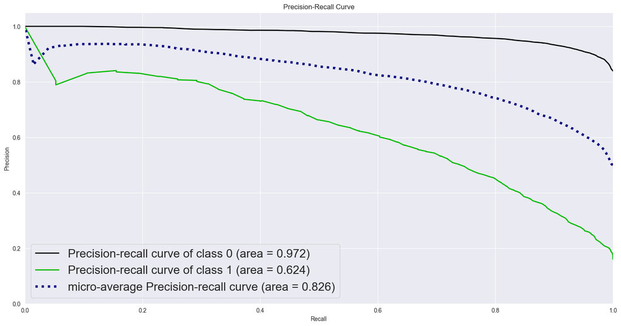

```python
unsampled_data_prediction_RF = rf_pipe.predict_proba(original_df_with_pcs[x_features])
skplt.metrics.plot_precision_recall(original_df_with_pcs['Attrition_Flag'], unsampled_data_prediction_RF)
plt.legend(prop={'size': 20})
```

## Interpreting the AUC Values

### **Precision-Recall Curve of Class 0 (AUC = 0.972):**

- This is high, indicating that the model can identify the 'not churn' class with high precision and recall. However, since this is for class 0, it is less relevant as we're specifically interested in identifying churn (class 1)

- This value is moderate, reflecting the model's ability to identify the 'churn' class. A lower AUC for the positive class indicates the model struggles more with correctly predicting churn than not churn, particularly in terms of distinguishing between true positives and false positives across different thresholds

## Overall Assessment

- The high AUC for the 'not churn' class and the overall micro-average suggest the model performs reasonably well overall, especially in distinguishing the negative cases
- The moderate AUC for the 'churn' class indicates room for improvement in precisely identifying churn cases, which is critical for predicting churn
- Given the importance of precisely identifying churn to allocate resources effectively or to intervene with customer retention strategies, focusing on improving the precision-recall balance for the churn class is important

## Upsampling is a great way to normalise, but there can be issues with it....especially if our unknown is part of the minority class

## Let's try undersampling, reducing the number of instances in our majority class

### Need to reinitialise and ohe data once more to start fresh

```python
ddf = pd.read_csv('bank-churn.csv')
ddf = ddf[ddf.columns[:-2]]
```

```python
ddf.Attrition_Flag = ddf.Attrition_Flag.replace({'Attrited Customer':1,'Existing Customer':0})
ddf.Gender = ddf.Gender.replace({'F':1,'M':0})
ddf = pd.concat([ddf,pd.get_dummies(ddf['Education_Level']).drop(columns=['Unknown'])],axis=1)
ddf = pd.concat([ddf,pd.get_dummies(ddf['Income_Category']).drop(columns=['Unknown'])],axis=1)
ddf = pd.concat([ddf,pd.get_dummies(ddf['Marital_Status']).drop(columns=['Unknown'])],axis=1)
ddf = pd.concat([ddf,pd.get_dummies(ddf['Card_Category']).drop(columns=['Platinum'])],axis=1)
ddf.drop(columns = ['Education_Level','Income_Category','Marital_Status','Card_Category','CLIENTNUM'],inplace=True)
```

```python
ddf.head(3)
```

|  | Attrition_Flag | Customer_Age | Gender | Dependent_count | Months_on_book | Total_Relationship_Count | Months_Inactive_12_mon | Contacts_Count_12_mon | Credit_Limit | Total_Revolving_Bal | ... | $40K - $60K | $60K - $80K | $80K - $120K | Less than $40K | Divorced | Married | Single | Blue | Gold | Silver |
| --- | --- | --- | --- | --- | --- | --- | --- | --- | --- | --- | --- | --- | --- | --- | --- | --- | --- | --- | --- | --- | --- |
| 0 | 0 | 45 | 0 | 3 | 39 | 5 | 1 | 3 | 12691.0 | 777 | ... | False | True | False | False | False | True | False | True | False | False |
| 1 | 0 | 49 | 1 | 5 | 44 | 6 | 1 | 2 | 8256.0 | 864 | ... | False | False | False | True | False | False | True | True | False | False |
| 2 | 0 | 51 | 0 | 3 | 36 | 4 | 1 | 0 | 3418.0 | 0 | ... | False | False | True | False | False | True | False | True | False | False |

3 rows × 33 columns

```python
from imblearn.under_sampling import RandomUnderSampler

udf = ddf.copy()

under_sampler = RandomUnderSampler(random_state=42)

X_under, y_under = under_sampler.fit_resample(udf[udf.columns[1:]], udf[udf.columns[0]])
undersampled_df = X_under.assign(Churn=y_under)
```

```python
under_ohe_data = undersampled_df[undersampled_df.columns[15:-1]].copy()

undersampled_df = undersampled_df.drop(columns=undersampled_df.columns[15:-1])
```

```python
fig = make_subplots(rows=2, cols=1,shared_xaxes=True,subplot_titles=('Pearson Correlation',  'Spearman Correlation'))
colorscale=     [[1.0              , "rgb(165,0,38)"],
                [0.8888888888888888, "rgb(215,48,39)"],
                [0.7777777777777778, "rgb(244,109,67)"],
                [0.6666666666666666, "rgb(253,174,97)"],
                [0.5555555555555556, "rgb(254,224,144)"],
                [0.4444444444444444, "rgb(224,243,248)"],
                [0.3333333333333333, "rgb(171,217,233)"],
                [0.2222222222222222, "rgb(116,173,209)"],
                [0.1111111111111111, "rgb(69,117,180)"],
                [0.0               , "rgb(49,54,149)"]]

s_val =undersampled_df.corr('pearson')
s_idx = s_val.index
s_col = s_val.columns
s_val = s_val.values
fig.add_trace(
    go.Heatmap(x=s_col,y=s_idx,z=s_val,name='pearson',showscale=False,xgap=1,ygap=1,colorscale=colorscale),
    row=1, col=1
)


s_val =undersampled_df.corr('spearman')
s_idx = s_val.index
s_col = s_val.columns
s_val = s_val.values
fig.add_trace(
    go.Heatmap(x=s_col,y=s_idx,z=s_val,xgap=1,ygap=1,colorscale=colorscale),
    row=2, col=1
)
fig.update_layout(
    hoverlabel=dict(
        bgcolor="white",
        font_size=16,
        font_family="Rockwell"
    )
)
fig.update_layout(height=900, width=1200, title_text="Undersampled Correlations")
fig.show()
```

[interactive chart not shown]

```python
N_COMPONENTS = 4

pca_model = PCA(n_components = N_COMPONENTS )

pca_matrix = pca_model.fit_transform(under_ohe_data)

evr = pca_model.explained_variance_ratio_
total_var = evr.sum() * 100
cumsum_evr = np.cumsum(evr)

trace1 = {
    "name": "individual explained variance",
    "type": "bar",
    'y':evr}
trace2 = {
    "name": "cumulative explained variance",
    "type": "scatter",
     'y':cumsum_evr}
data = [trace1, trace2]
layout = {
    "xaxis": {"title": "Principal components"},
    "yaxis": {"title": "Explained variance ratio"},
  }
fig = go.Figure(data=data, layout=layout)
fig.update_layout(height=700, width=900, title='Explained Variance Using {} Dimensions'.format(N_COMPONENTS))
fig.show()
```

[interactive chart not shown]

## More than 50% of the variance can be explained by PC-3

Better than last time!

```python
underloadings = pca_model.components_.T  # Transpose to align with (features, components)

underloadings_df = pd.DataFrame(underloadings, columns=['PC-{}'.format(i) for i in range(N_COMPONENTS)], index=under_ohe_data.columns)

underloadings_df
```

|  | PC-0 | PC-1 | PC-2 | PC-3 |
| --- | --- | --- | --- | --- |
| College | 0.007280 | -0.053315 | -0.070495 | 0.146399 |
| Doctorate | 0.005112 | 0.000413 | -0.038720 | 0.045054 |
| Graduate | -0.053822 | 0.328133 | 0.802609 | -0.228127 |
| High School | -0.004498 | -0.163299 | -0.415959 | -0.720085 |
| Post-Graduate | 0.007300 | -0.022051 | -0.030470 | 0.046098 |
| Uneducated | 0.029443 | -0.068016 | -0.163758 | 0.618882 |
| $120K + | 0.009603 | -0.074704 | 0.003262 | 0.015175 |
| $40K - $60K | 0.001929 | -0.279271 | 0.159790 | 0.016602 |
| $60K - $80K | -0.008111 | -0.179026 | 0.031876 | -0.079113 |
| $80K - $120K | 0.014867 | -0.219296 | 0.112429 | 0.039781 |
| Less than $40K | -0.023297 | 0.829996 | -0.327274 | 0.010094 |
| Divorced | 0.010151 | -0.002860 | 0.000053 | 0.074712 |
| Married | -0.713749 | -0.028117 | -0.020864 | -0.017925 |
| Single | 0.695671 | 0.034640 | 0.031062 | -0.069682 |
| Blue | -0.032258 | 0.042287 | -0.024067 | 0.029665 |
| Gold | 0.007061 | -0.006905 | 0.004844 | -0.002885 |
| Silver | 0.023858 | -0.035558 | 0.016486 | -0.027140 |

```python
print(undersampled_df['Credit_Limit'].isna().sum())
```

```
0
```

```python
undersampled_df_reset = undersampled_df.reset_index(drop=True)
pca_df = pd.DataFrame(pca_matrix, columns=['PC-{}'.format(i) for i in range(N_COMPONENTS)]).reset_index(drop=True)

# Concatenate the reset DataFrames to avoid NaN values introduced by index misalignment
undersampled_df_with_pcs = pd.concat([undersampled_df_reset, pca_df], axis=1)
```

```python
undersampled_df_with_pcs.columns
```

```
Index(['Customer_Age', 'Gender', 'Dependent_count', 'Months_on_book',
       'Total_Relationship_Count', 'Months_Inactive_12_mon',
       'Contacts_Count_12_mon', 'Credit_Limit', 'Total_Revolving_Bal',
       'Avg_Open_To_Buy', 'Total_Amt_Chng_Q4_Q1', 'Total_Trans_Amt',
       'Total_Trans_Ct', 'Total_Ct_Chng_Q4_Q1', 'Avg_Utilization_Ratio',
       'Churn', 'PC-0', 'PC-1', 'PC-2', 'PC-3'],
      dtype='object')
```

```python
print(undersampled_df_with_pcs['Credit_Limit'].isna().sum())
```

```
0
```

```python
fig = ex.scatter_matrix(
    undersampled_df_with_pcs[['PC-{}'.format(i) for i in range(0,N_COMPONENTS)]].values,
    color=undersampled_df_with_pcs.Credit_Limit,
    dimensions=range(N_COMPONENTS),
    labels={str(i):'PC-{}'.format(i) for i in range(0,N_COMPONENTS)},
    title=f'Total Explained Variance: {total_var:.2f}%')

fig.update_traces(diagonal_visible=False)
fig.update_layout(
    height=900, width=1200,
    coloraxis_colorbar=dict(
        title="Credit_Limit"
    ),
)
fig.show()
```

[interactive chart not shown]

```python
fig = make_subplots(rows=2, cols=1,shared_xaxes=True,subplot_titles=('Pearson Correlation',  'Spearman Correlation'))


s_val =undersampled_df_with_pcs.corr('pearson')
s_idx = s_val.index
s_col = s_val.columns
s_val = s_val.values
fig.add_trace(
    go.Heatmap(x=s_col,y=s_idx,z=s_val,name='pearson',showscale=False,xgap=1,ygap=1,colorscale=colorscale),
    row=1, col=1
)


s_val =undersampled_df_with_pcs.corr('spearman')
s_idx = s_val.index
s_col = s_val.columns
s_val = s_val.values
fig.add_trace(
    go.Heatmap(x=s_col,y=s_idx,z=s_val,xgap=1,ygap=1,colorscale=colorscale),
    row=2, col=1
)
fig.update_layout(
    hoverlabel=dict(
        bgcolor="white",
        font_size=16,
        font_family="Rockwell"
    )
)
fig.update_layout(height=700, width=900, title_text="Undersampled Correlations With PCs")
fig.show()
```

[interactive chart not shown]

```python
undersampled_df_with_pcs.columns
```

```
Index(['Customer_Age', 'Gender', 'Dependent_count', 'Months_on_book',
       'Total_Relationship_Count', 'Months_Inactive_12_mon',
       'Contacts_Count_12_mon', 'Credit_Limit', 'Total_Revolving_Bal',
       'Avg_Open_To_Buy', 'Total_Amt_Chng_Q4_Q1', 'Total_Trans_Amt',
       'Total_Trans_Ct', 'Total_Ct_Chng_Q4_Q1', 'Avg_Utilization_Ratio',
       'Churn', 'PC-0', 'PC-1', 'PC-2', 'PC-3'],
      dtype='object')
```

```python
x_features = ['Total_Trans_Ct','PC-3','PC-1','PC-0','PC-2','Total_Ct_Chng_Q4_Q1','Total_Relationship_Count']

x = undersampled_df_with_pcs[x_features]
y = undersampled_df_with_pcs['Churn']
```

```python
print(f"Number of NaN values in target variable: {undersampled_df_with_pcs['Churn'].isna().sum()}")
```

```
Number of NaN values in target variable: 0
```

```python
train_x,test_x,train_y,test_y = train_test_split(x,y,random_state=42)
```

```python
rf_pipe = Pipeline(steps =[ ('scale',StandardScaler()), ("RF",RandomForestClassifier(random_state=42)) ])
ada_pipe = Pipeline(steps =[ ('scale',StandardScaler()), ("RF",AdaBoostClassifier(random_state=42,learning_rate=0.7)) ])
svm_pipe = Pipeline(steps =[ ('scale',StandardScaler()), ("RF",SVC(random_state=42,kernel='rbf')) ])


f1_cross_val_scores = cross_val_score(rf_pipe,train_x,train_y,cv=5,scoring='f1')
ada_f1_cross_val_scores=cross_val_score(ada_pipe,train_x,train_y,cv=5,scoring='f1')
svm_f1_cross_val_scores=cross_val_score(svm_pipe,train_x,train_y,cv=5,scoring='f1')
```

```python
fig = make_subplots(rows=3, cols=1,shared_xaxes=True,subplot_titles=('Random Forest Cross Val Scores',
                                                                     'Adaboost Cross Val Scores',
                                                                    'SVM Cross Val Scores'))

fig.add_trace(
    go.Scatter(x=list(range(0,len(f1_cross_val_scores))),y=f1_cross_val_scores,name='Random Forest'),
    row=1, col=1
)
fig.add_trace(
    go.Scatter(x=list(range(0,len(ada_f1_cross_val_scores))),y=ada_f1_cross_val_scores,name='Adaboost'),
    row=2, col=1
)
fig.add_trace(
    go.Scatter(x=list(range(0,len(svm_f1_cross_val_scores))),y=svm_f1_cross_val_scores,name='SVM'),
    row=3, col=1
)

fig.update_layout(height=700, width=900, title_text="Different Model 5 Fold Cross Validation")
fig.update_yaxes(title_text="F1 Score")
fig.update_xaxes(title_text="Fold #")

fig.show()
```

[interactive chart not shown]

```python
rf_pipe.fit(train_x,train_y)
rf_prediction = rf_pipe.predict(test_x)

ada_pipe.fit(train_x,train_y)
ada_prediction = ada_pipe.predict(test_x)

svm_pipe.fit(train_x,train_y)
svm_prediction = svm_pipe.predict(test_x)
```

```python
fig = go.Figure(data=[go.Table(header=dict(values=['<b>Model<b>', '<b>F1 Score On Test Data<b>'],
                                           line_color='darkslategray',
                                           fill_color='whitesmoke',
                                           align=['center','center'],
                                           font=dict(color='black', size=18),
                                           height=40),
                                           cells=dict(values=[['<b>Random Forest<b>', '<b>AdaBoost<b>','<b>SVM<b>'],
                                                              [np.round(f1(rf_prediction,test_y),2),
                                                               np.round(f1(ada_prediction,test_y),2),
                                                               np.round(f1(svm_prediction,test_y),2)]]))])

fig.update_layout(title='Model Results On Test Data')
fig.show()
```

[interactive chart not shown]

```python
under_ohe_data =udf[udf.columns[16:]].copy()
pca_matrix = pca_model.fit_transform(under_ohe_data)
ori_df_with_pcs = pd.concat([udf,pd.DataFrame(pca_matrix,columns=['PC-{}'.format(i) for i in range(0,N_COMPONENTS)])],axis=1)

unsampled_data_prediction_RF = rf_pipe.predict(ori_df_with_pcs[x_features])
unsampled_data_prediction_ADA = ada_pipe.predict(ori_df_with_pcs[x_features])
unsampled_data_prediction_SVM = svm_pipe.predict(ori_df_with_pcs[x_features])
```

```python
fig = go.Figure(data=[go.Table(header=dict(values=['<b>Model<b>', '<b>F1 Score On Original Data (Before Undersampling)<b>'],
                                           line_color='darkslategray',
                                           fill_color='whitesmoke',
                                           align=['center','center'],
                                           font=dict(color='black', size=18),
                                           height=40),
                                           cells=dict(values=[['<b>Random Forest<b>', '<b>AdaBoost<b>','<b>SVM<b>'],
                                                              [np.round(f1(unsampled_data_prediction_RF,ori_df_with_pcs['Attrition_Flag']),2),
                                                               np.round(f1(unsampled_data_prediction_ADA,ori_df_with_pcs['Attrition_Flag']),2),
                                                               np.round(f1(unsampled_data_prediction_SVM,ori_df_with_pcs['Attrition_Flag']),2)]]))])

fig.update_layout(title='Model Result On Original Data (Without Upsampling)')
fig.show()
```

[interactive chart not shown]

```python
z=confusion_matrix(unsampled_data_prediction_RF,ori_df_with_pcs['Attrition_Flag'])
fig = ff.create_annotated_heatmap(z, x=['Not Churn','Churn'], y=['Predicted Not Churn','Predicted Churn'], colorscale='rdbu',xgap=3,ygap=3)
fig['data'][0]['showscale'] = True
fig.update_layout(height=700, width=900, title='Prediction On Original Data With Random Forest Model Confusion Matrix')
fig.show()
```

[interactive chart not shown]

```python
TP = 1457
TN = 7110
FP = 1390
FN = 170

accuracy = (TP + TN) / (TP + TN + FP + FN)
precision = TP / (TP + FP)
recall = TP / (TP + FN)
f1_score = 2 * (precision * recall) / (precision + recall)

print('accuracy: ', accuracy)
print('precision: ', precision)
print('recall: ', recall)
print('f1 score: ', f1_score)
```

```
accuracy:  0.8459563543003851
precision:  0.5117667720407446
recall:  0.8955132145052244
f1 score:  0.6513187304425571
```

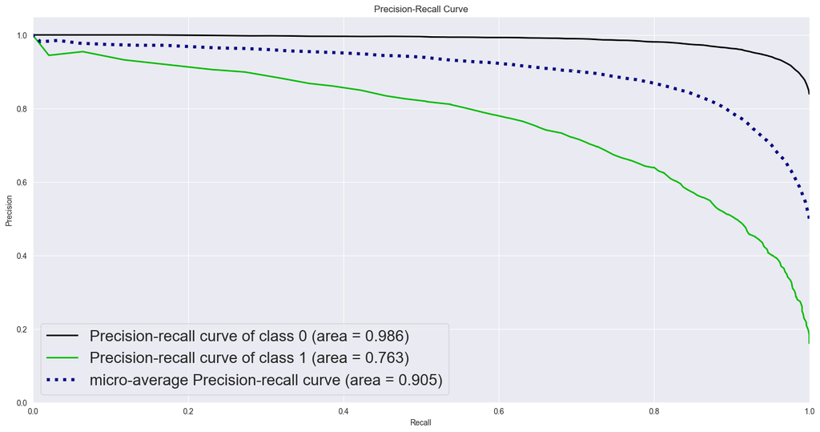

```python
unsampled_data_prediction_RF = rf_pipe.predict_proba(ori_df_with_pcs[x_features])
skplt.metrics.plot_precision_recall(ori_df_with_pcs['Attrition_Flag'], unsampled_data_prediction_RF)
plt.legend(prop={'size': 20})
```

```python
random_forest_model = rf_pipe.named_steps["RF"]

feature_importances = random_forest_model.feature_importances_
feature_names = train_x.columns

feature_importance_dict = dict(zip(feature_names, feature_importances))

sorted_features = sorted(feature_importance_dict.items(), key=lambda item: item[1], reverse=True)

for feature, importance in sorted_features:
    print(f"{feature}: {importance}")
```

```
Total_Trans_Ct: 0.3983881247311804
Total_Ct_Chng_Q4_Q1: 0.2456211104446931
Total_Relationship_Count: 0.10358200931631809
PC-0: 0.06880617970359189
PC-1: 0.06235495255375434
PC-3: 0.06093585411873605
PC-2: 0.060311769131726194
```

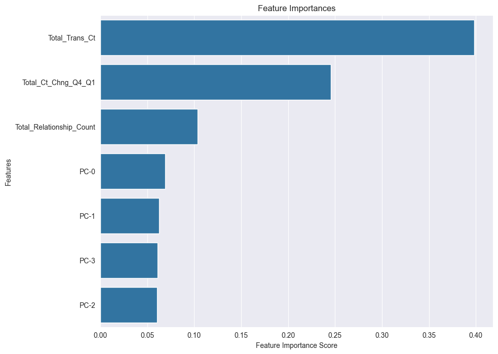

```python
feature_importances_df = pd.DataFrame(sorted_features, columns=['Feature', 'Importance'])

plt.figure(figsize=(10, 8))
sns.barplot(x='Importance', y='Feature', data=feature_importances_df)

plt.xlabel('Feature Importance Score')
plt.ylabel('Features')
plt.title('Feature Importances')
plt.show()
```

## Interpreting the AUC Values

### **Precision-Recall Curve of Class 0 (AUC = 0.986):**

- No real change from the 'upsampling' result. Extremely effective at identifying customers who will not churn

### **Precision-Recall Curve of Class 1 (AUC = 0.763):**

- Undersampling actually increased the our model's ability to identify churning customers 🎉🎉🎉
- Pretty happy with this considering the classes are imbalanced

### **Micro-Average Precision-Recall Curve (AUC = 0.905):**

- Huge increase from the upsampling model
- The model performs well overall across both classes

## Overall Assessment

- Decently high scores across all metrics reflect well on the model's performance
- After applying undersampling to address class imbalance, the scores show that the model is reliable in predicting non-churn and fairly effective at identifying churn
- Techniques to further improve churn prediction could provide even more value

## Feature importance for this model

#### **Total_Trans_Ct (39.84% importance):**

- This is the most influential feature. It likely represents the total count of transactions made by a customer, which indicates that the frequency of transactions is a strong predictor of the target variable

#### **Total_Ct_Chng_Q4_Q1 (24.56% importance):**

- Indicating the change in transaction count from one quarter to another is also highly predictive. Significant changes in how often a customer engages can signal changes in customer behavior, potentially leading to churn

#### **Total_Relationship_Count (10.36% importance):**

- This might represent the number of different types of relationships or products a customer has with the bank
- A higher number of relationships can increase customer stickiness, affecting churn